# second week: Introduction to R and Rstudio

Mobile Data

Aida Ramezani 95105595

2018-02-25 15:59:05

# تمرین سری دوم: تلفن همراه شناسی!

```
## [1] "Samsung"
```

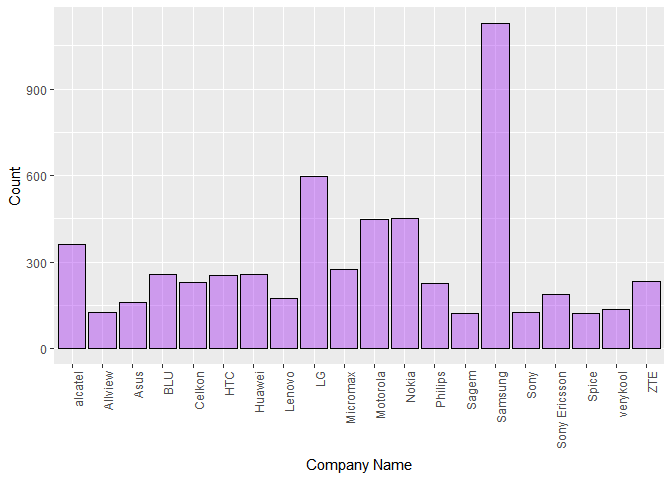

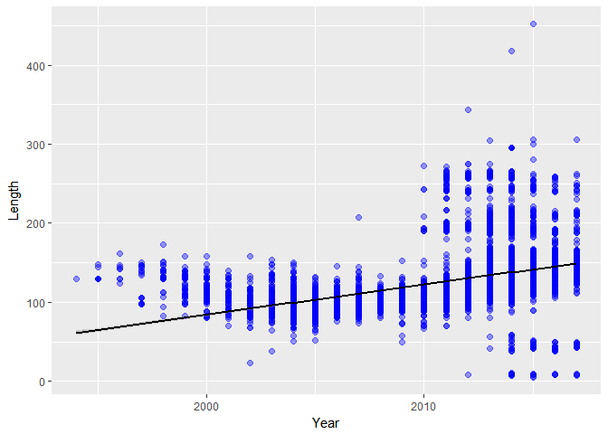

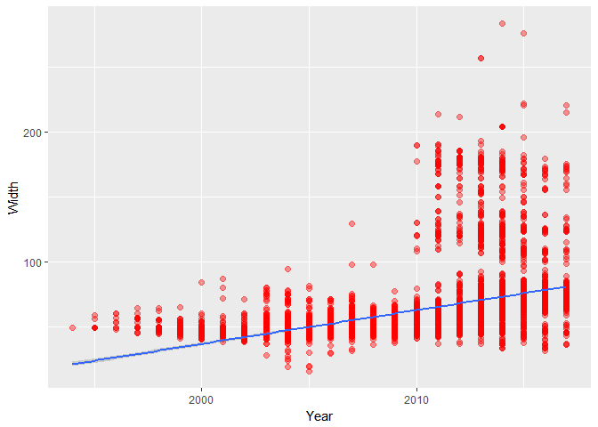

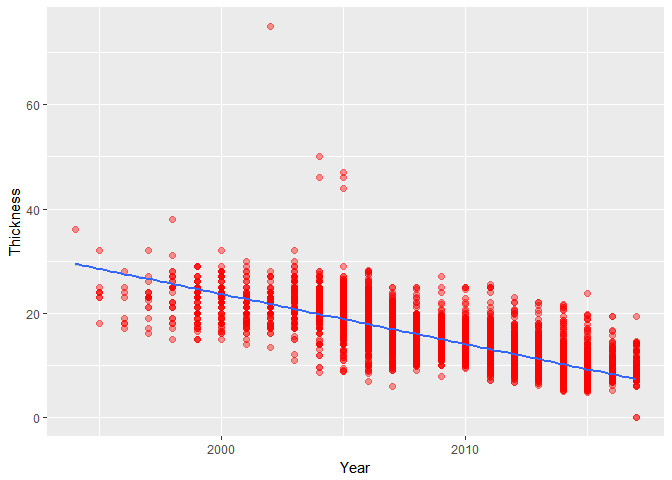

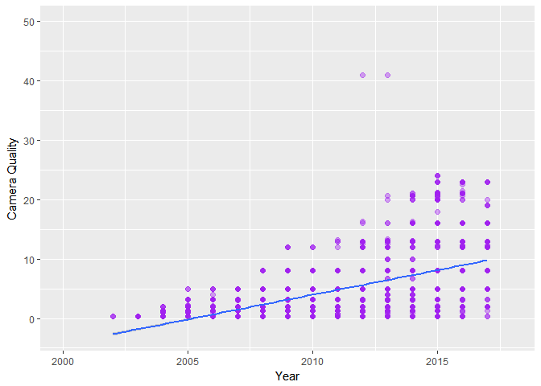

نکته قابل توجه این است که در نمودار کیفیت دوربین بر حسب زمان، با توجه به انتظاراتمان، قابلیت دوربین از سال 2000 به بعد به گوشی های تلفن اضافه شده است.

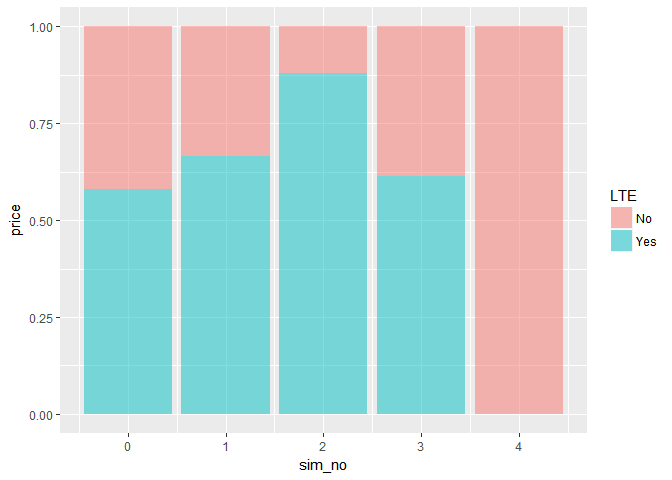

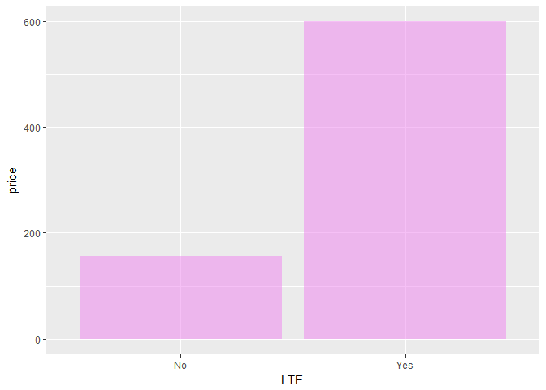

مشاهده میشود که گوشی های گرانقیمت غالبا دارای قابلیت فوق میباشند.

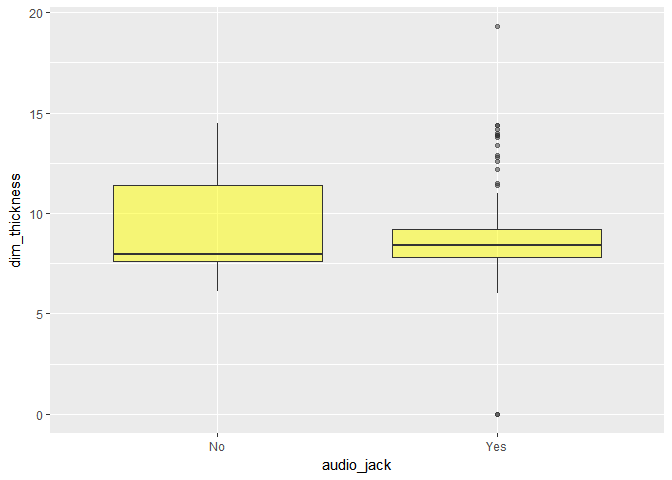

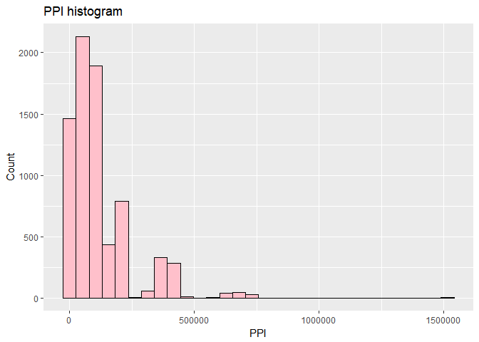

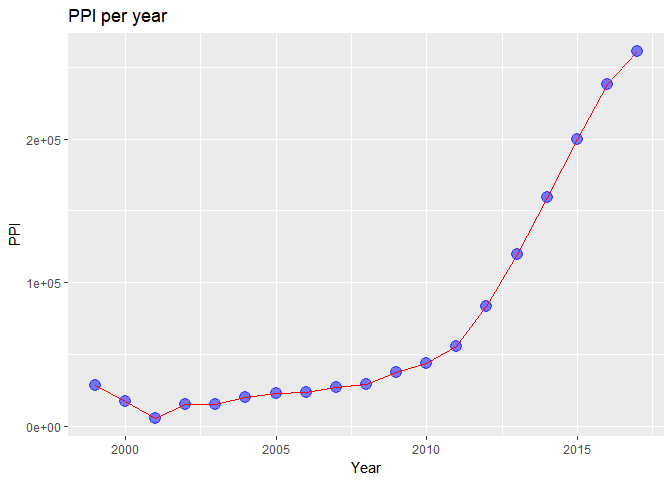

6. $Gooshkoobiat = \frac{weight * 1000}{ breadth * length * thickness * price}$

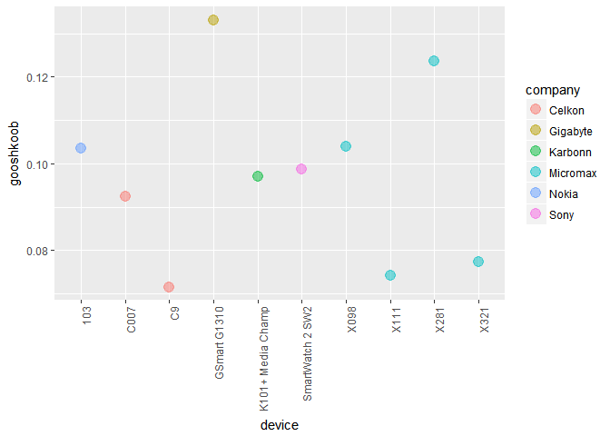

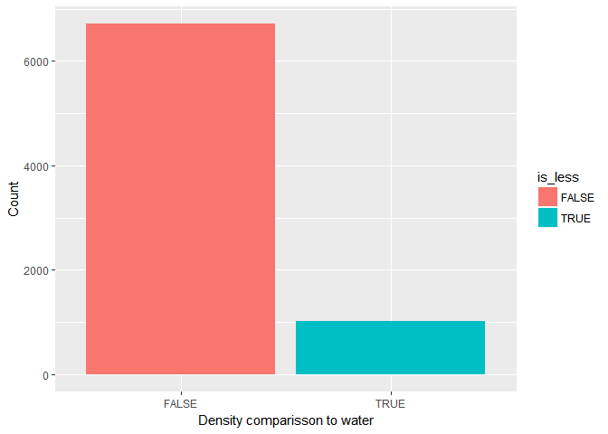

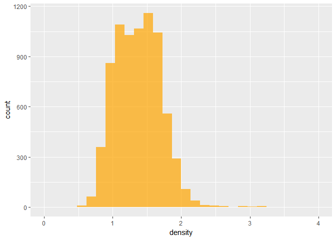

```
##  [1] "2040"   "OT-308" "OT-292" "OT-228" "OT-665" "OT-361" "OT-223"
##  [8] "OT-217" "OT-213" "OT-209"
```

8. در نمودار زیر حجم ذخیره سازی باتری بر حسب وزن تلفن همراه کشیده شده است. همچنین همبستگی این دو ویژگی توسط یک خط نمایان است.

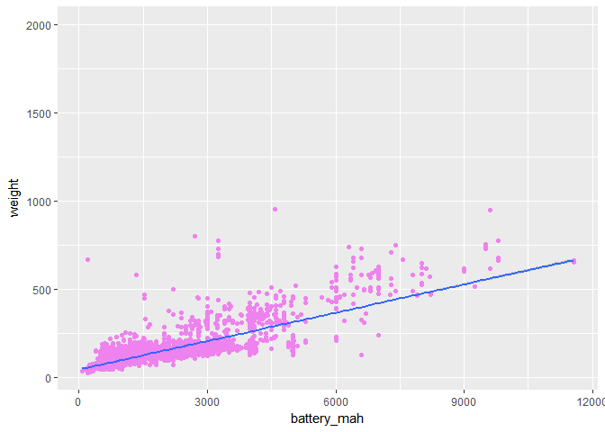

```
## (Intercept)
##    44.40726
```

```
## battery_mah
##  0.05369323
```

9. پرچم داران سامسونگ تلفن های همراهی هستند که قیمت آن ها از حدی بالاتر است.

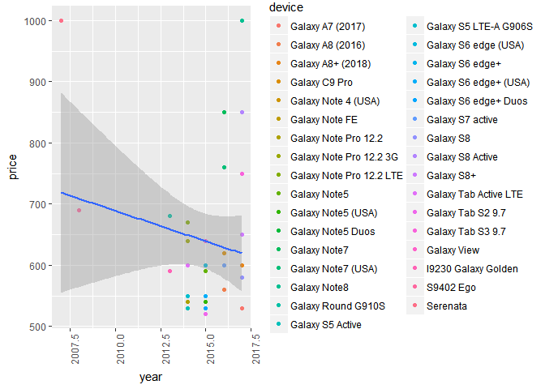

   ***

نمودار اول نشانده نسبت طول به عرض تلفن همراه میباشد. همچنین مشاهده کرده ام که با چه مقداری برای طول و عرض گوشی، در دست گرفتن و کار کردن با آن راحت تر است. همانطور که مشاهده میشود، تعداد بسیار کمی از گوشی ها در این اندازه گیری صدق میکنند. برای مثال گوشی های قدیمی تر مستطیلی و باریک تر و گوشی های جدید بسیار بزرگ هستند

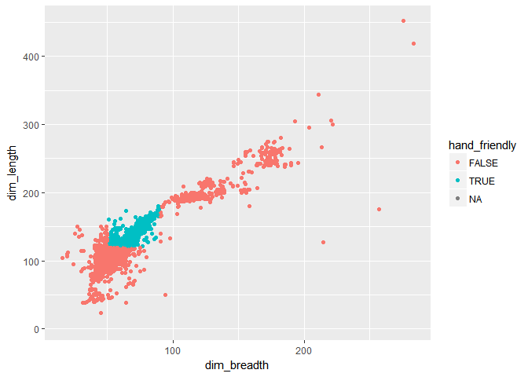

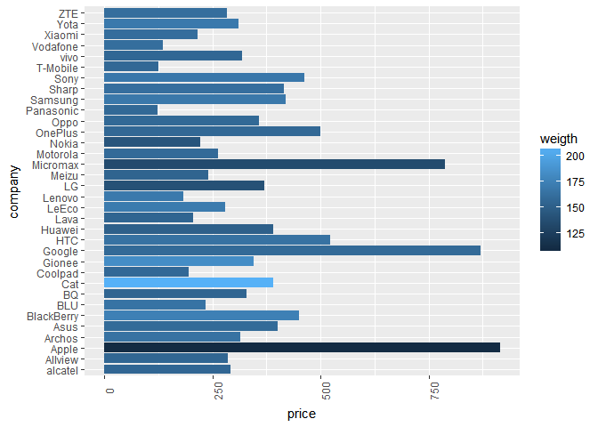

در نمودار سوم، محور افقی نشان دهنده امتیاز تلفن همراه است. امتیاز تلفن همراه بر اساس قابلیت های آن برای مثال قابلیت جی پی اس داشتن، محاسبه میشود. همچنین نمودار عمودی بیانگر، حجم ذخیره باتری میباشد. همچنین این نمودار بر اساس میانگین هر شرکت سازنده تهیه شده است. همان طور که میبینید، با زیادشدن قابلیت های تلفن های همراه، حجم ذخیره باتری در پی آن باید افزایش یابد و روندی صعودی دارد.

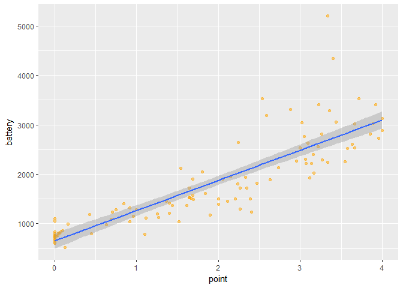